# Chapter 13

jim108@gmx.net

6/15/2020

## 13E1.

Want: Which of the following priors will produce more shrinkage in the estimates?

1. $\alpha_{TANK} \sim Normal(0, 1)$
2. $\alpha_{TANK} \sim Normal(0, 2)$.

Sol: 1. The variance is lower, it is more a regularizing prior.

## 13E2.

Given:

$y_i \sim Binomial(1, p_i)$

$logit(p_i) = \alpha_{GROUP[i]} + \beta x_i$

$\alpha_{GROUP} \sim Normal(0,10)$

$\beta \sim Normal(0,1)$.

Want: Multilevel model.

Sol.:

$y_i \sim Normal(1, p_i)$

$logit(p_i) = \alpha_{GROUP[i]} + \beta_i x_i$

$\alpha_{j} \sim Normal(\mu_{\alpha},\sigma_{\alpha})$

$\mu_{\alpha} \sim Normal(0, 10)$

$\sigma_{\alpha} \sim Exp(1/10)$

$\beta_j \sim Normal(\mu_{\beta},\sigma_{\beta})$

$\mu_{\beta} \sim Normal(0, 1)$

$\sigma_{\beta} \sim Exp(1)$.

## 13E3.

Given:

$y_i \sim Normal(\mu_i, \sigma)$

$\mu_i = \alpha_{GROUP[i]} + \beta x_i$

$\alpha_{GROUP} \sim Normal(0,10)$

$\beta \sim Normal(0,1)$

$\sigma \sim HalfCauchy(0,2)$.

Want: Multilevel model.

Sol.:

$y_i \sim Normal(\mu_i, \sigma)$

$\mu_i = \alpha_{GROUP[i]} + \beta_i x_i$

$\alpha_j \sim Normal(\mu_{\alpha},\sigma_{\alpha})$

$\mu_{\alpha} \sim Normal(0, 10)$

$\sigma_{\alpha} \sim Exp(1/10)$

$\beta_j \sim Normal(\mu_{\beta},\sigma_{\beta})$

$\mu_{\beta} \sim Normal(0, 1)$

$\mu_{\beta} \sim Exp(1)$

$\sigma \sim HalfCauchy(0,2)$.

## 13E4.

Want: Mathematical model formula for a Poisson regression with varying intercepts.

Sol.:

E. g. waiting time for a response email (T) depending on sender group (G).

$T_i \sim Poisson(\lambda_i)$

$log(\lambda_i) = \alpha_{G[i]}$

$\alpha_{j} \sim Normal( \mu_{\alpha}, \sigma_{\alpha})$

$\mu_{\alpha} \sim Normal(0, 1)$

$\sigma_{\alpha} \sim Exp(1)$.

## 13E5.

Want: Mathematical model formula for a Poisson regression with two different kinds of varying intercepts, a cross-classified model.

Sol.:

E. g. waiting time for a response email (T) depending on sender group (G) and hour send (H).

$T_i \sim Poisson(\lambda_i)$

$log(\lambda_i) = \alpha_{G[i]} + \beta_{H[i]}$

$\alpha_{j} \sim Normal( \mu_{\alpha}, \sigma_{\alpha})$

$\mu_{\alpha} \sim Normal(0, 1)$

$\sigma_{\alpha} \sim Exp(1)$

$\beta_{j} \sim Normal( \mu_{\beta}, \sigma_{\beta})$

$\mu_{\beta} \sim Normal(0, 1)$

$\sigma_{\beta} \sim Exp(1)$.

## 13M1.

Given: Tadpoles data.

Want: Add `predation` and `size` treatment variables. Model main effect alone, both main effects, main effects and interaction. Why does the variation change across models?

Sol.:

```r
data(reedfrogs)
d <- reedfrogs
str(d)
```

```
## 'data.frame':    48 obs. of  5 variables:
##  $ density : int  10 10 10 10 10 10 10 10 10 10 ...
##  $ pred    : Factor w/ 2 levels "no","pred": 1 1 1 1 1 1 1 1 2 2 ...
##  $ size    : Factor w/ 2 levels "big","small": 1 1 1 1 2 2 2 2 1 1 ...
##  $ surv    : int  9 10 7 10 9 9 10 9 4 9 ...
##  $ propsurv: num  0.9 1 0.7 1 0.9 0.9 1 0.9 0.4 0.9 ...
```

```r
d$tank <- 1:nrow(d)

dat <- list(
    S = d$surv,
    N = d$density,
    pred = d$pred,
    siz = d$size,
    tank = d$tank )
```

```r
# Original model
m13.2 <- ulam(
    alist(
        S ~ dbinom( N , p ) ,
        logit(p) <- a[tank] ,
        a[tank] ~ dnorm( a_bar , sigma ) ,
        a_bar ~ dnorm( 0 , 1.5 ) ,
        sigma ~ dexp( 1 )
    ), data=dat , chains=4 , log_lik=TRUE )
```

```
## Trying to compile a simple C file
```

```r
# 95 % interval for a_pred.
cat(inv_logit(-0.2),inv_logit(0.2))
```

```
## 0.450166 0.549834
```

```r
# weaker priors lead to non-effictive sampling.
```

```r
# Model with predator
m13M1p <- ulam(
    alist(
        S ~ dbinom( N , p ) ,
        logit(p) <- a_tank[tank] + b_pred*pred ,
        a_tank[tank] ~ dnorm( a , sigma ) ,
        a ~ dnorm(0,1.5) ,
        sigma ~ dexp(1),
        b_pred ~ dnorm(0,0.1)
    ), data=dat , chains=4 , cores=4, log_lik=TRUE )
```

```
## Trying to compile a simple C file
```

```r
# Model with size
m13M1s <- ulam(
    alist(
        S ~ dbinom( N , p ) ,
        logit(p) <- a_tank[tank] + b_siz*siz,
        a_tank[tank] ~ dnorm( a , sigma ) ,
        a ~ dnorm(0,1.5) ,
        sigma ~ dexp(1),
        b_siz ~ dnorm(0,0.1)
    ), data=dat , chains=4 , cores=4, log_lik=TRUE )
```

```
## Trying to compile a simple C file
```

```r
# Model with predator and size
m13M1ps <- ulam(
    alist(
        S ~ dbinom( N , p ) ,
        logit(p) <- a_tank[tank] + b_pred*pred + b_siz*siz,
        a_tank[tank] ~ dnorm( a , sigma ) ,
        a ~ dnorm(0,1.5) ,
        sigma ~ dexp(1),
        b_pred ~ dnorm(0,0.05),
        b_siz ~ dnorm(0, 0.05)
    ), data=dat , chains=4 , cores=4, log_lik=TRUE )
```

```
## Trying to compile a simple C file
```

```r
# Model with predator and size + interaction
m13M1psi <- ulam(
    alist(
        S ~ dbinom( N , p ) ,
        logit(p) <- a_tank[tank] + b_pred*pred + b_ps*pred*siz + b_siz*siz,
        a_tank[tank] ~ dnorm( a , sigma ) ,
        a ~ dnorm(0,1.5) ,
        sigma ~ dexp(1),
        b_pred ~ dnorm(0,0.05),
        b_siz ~ dnorm(0, 0.05),
        b_ps ~ dnorm(0, 0.05)
    ), data=dat , chains=4 , cores=4, log_lik=TRUE )
```

```
## Trying to compile a simple C file
```

```r
precis(m13M1p)
```

```
## 48 vector or matrix parameters hidden. Use depth=2 to show them.
```

```
##               mean         sd       5.5%      94.5%     n_eff    Rhat4
## a       1.47299187 0.28125014  1.0342935 1.92686440  906.2741 1.000186
## sigma   1.57431230 0.21325463  1.2500524 1.93168643 1148.3801 1.000781
## b_pred -0.09139838 0.09934586 -0.2474467 0.06880296  485.9777 1.003389
```

```r
precis(m13M1s)
```

```
## 48 vector or matrix parameters hidden. Use depth=2 to show them.
```

```
##             mean         sd       5.5%     94.5%     n_eff    Rhat4
## a     1.30602324 0.28230401  0.8638826 1.7693396  956.7109 1.001265
## sigma 1.62141381 0.22051949  1.3072825 1.9860085 1354.5020 1.003996
## b_siz 0.02825948 0.09705818 -0.1252879 0.1834532  618.4523 1.004466
```

```r
precis(m13M1ps)
```

```
## 48 vector or matrix parameters hidden. Use depth=2 to show them.
```

```
##                mean         sd        5.5%      94.5%    n_eff     Rhat4
## a       1.365079788 0.27586506  0.93847667 1.80719852 1759.368 0.9996044
## sigma   1.604329520 0.21160386  1.29029821 1.96419055 1553.620 1.0001147
## b_pred -0.025102826 0.05145518 -0.10633861 0.05953987 1132.210 1.0022539
## b_siz   0.007307724 0.04957449 -0.06945659 0.09027514 1716.080 1.0001276
```

```r
precis(m13M1psi)
```

```
## 48 vector or matrix parameters hidden. Use depth=2 to show them.
```

```
##               mean         sd        5.5%      94.5%     n_eff     Rhat4
## a       1.42613009 0.28725944  0.95573705 1.87955120  876.4968 0.9990969
## sigma   1.60366251 0.20857299  1.29291739 1.97584994 1182.4706 0.9991309
## b_pred -0.02359617 0.04900288 -0.09954022 0.05414262 1588.3460 0.9986456
## b_siz   0.00712619 0.04980852 -0.06966306 0.08739430 1642.2281 0.9998279
## b_ps   -0.02585117 0.04979998 -0.10631336 0.05535976  748.8312 1.0009960
```

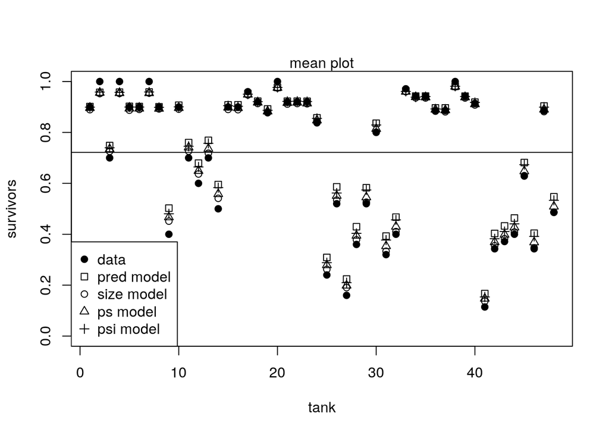

```r
models <- c(m13M1p, m13M1s, m13M1ps, m13M1psi)
precis_list <- sapply(models, function(m) precis(m, depth=2))

plot(d$tank, d$propsurv, ylim=c(0,1), pch=19, xlab="tank", ylab="survivors")
abline(h=mean(d$propsurv))
for (i in 1:length(models)) {
  p_a <-inv_logit(precis_list[,i]$mean[1:48])
#  abline( h=mean(p_a) , lty=i )
  points(d$tank, p_a, pch=i-1)
}
legend("bottomleft", legend=c("data", "pred model", "size model", "ps model", "psi model"),
       pch=c(19,0,1,2,3))
mtext("mean plot")
```

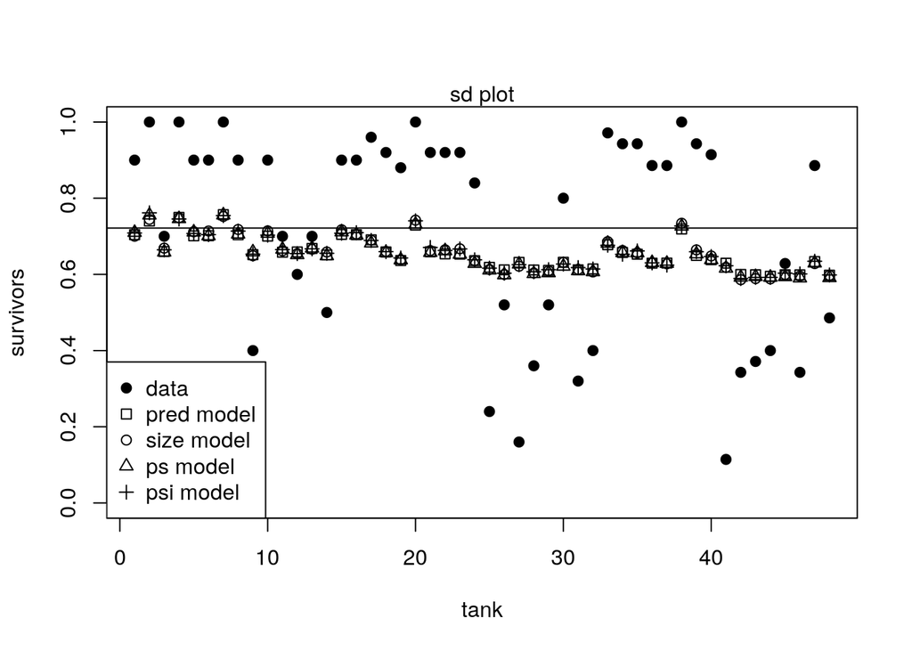

```r
plot(d$tank, d$propsurv, ylim=c(0,1), pch=19, xlab="tank", ylab="survivors")
abline(h=mean(d$propsurv))
for (i in 1:length(models)) {
  p_a <-inv_logit(precis_list[,i]$sd[1:48])
  points(d$tank, p_a, pch=i-1)
}
legend("bottomleft", legend=c("data", "pred model", "size model", "ps model", "psi model"),
       pch=c(19,0,1,2,3))
mtext("sd plot")
```

- The mean plot shows that the predictions shrink to the mean in the following order: pred model, pred and size interation model, pred and size model, size model.
- The sd plot does not show significat change in the standard deviation resp. variance.

## 13M2.

Given: 13M1.

Want: Compare WAIC.

Sol.:

```r
compare( m13M1p, m13M1s, m13M1ps, m13M1psi )
```

```
##              WAIC       SE     dWAIC      dSE    pWAIC    weight
## m13M1ps  199.8087 7.186864 0.0000000       NA 20.78516 0.3026178
## m13M1p   200.0167 7.378052 0.2079913 1.271266 20.86850 0.2727280
## m13M1psi 200.4124 7.098603 0.6037275 1.152197 21.05810 0.2237673
## m13M1s   200.6282 7.253127 0.8194560 1.087151 21.18040 0.2008870
```

Given: Tadpoles data,

```r
m13.2 <- ulam(
    alist(
        S ~ dbinom( N , p ) ,
        logit(p) <- a[tank] ,
        a[tank] ~ dnorm( a_bar , sigma ) ,
        a_bar ~ dnorm( 0 , 1 ) ,
        sigma ~ dexp( 1 )
    ), data=dat , chains=4 , cores = 4, log_lik=TRUE )
```

```
## Trying to compile a simple C file
```

Want: Replace `a[tank] ~ dnorm( a_bar , sigma )` by `a[tank] ~ dcauchy( a_bar , sigma )`. Compare intercepts.

Sol.:

```r
m13M3 <- ulam(
    alist(
        S ~ dbinom( N , p ) ,
        logit(p) <- a[tank] ,
        a[tank] ~ dcauchy( a_bar , sigma ) ,
        a_bar ~ dnorm( 0 , 1 ) ,
        sigma ~ dexp( 1 )
    ), data=dat , chains=4 , cores = 4, log_lik=TRUE, iter=1e4, control = list(adapt_delta=0.99) )
```

```
## Trying to compile a simple C file
```

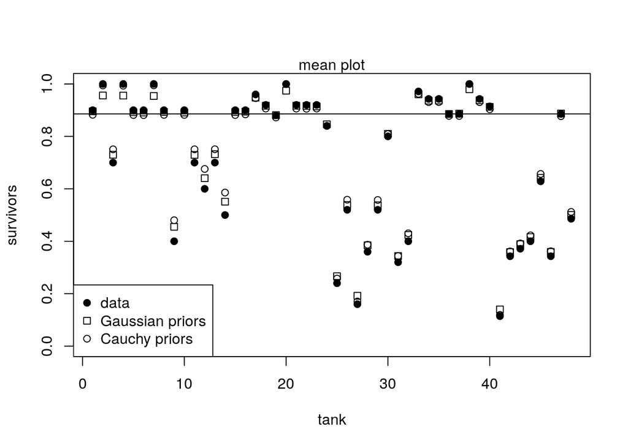

```r
models <- c(m13.2, m13M3)
precis_list <- sapply(models, function(m) precis(m, depth=2))

plot(d$tank, d$propsurv, ylim=c(0,1), pch=19, xlab="tank", ylab="survivors")
abline(h=median(d$propsurv))
for (i in 1:length(models)) {
  p_a <-inv_logit(precis_list[,i]$mean[1:48])
#  abline( h=median(p_a) , lty=i )
  points(d$tank, p_a, pch=i-1)
}
legend("bottomleft", legend=c("data", "Gaussian priors", "Cauchy priors"),
       pch=c(19,0,1))
mtext("mean plot")
```

- Increase the number of iterations and the adaptive delta did not solve for divergent transitions for the model with the Cauchy priors.
- The mean plot shows, for predictions below the mean, Cauchy priors regularize more than Gaussians, above it is the opposite.

## 13M4.

Given: Chimpanzee data.

Want: Use an adaptive prior for blocks:

$\gamma_j \sim Normal(\bar{\gamma},\sigma)$

$\bar{\gamma} \sim Normal(0, 1.5)$

Sol.:

```r
data(chimpanzees)
d <- chimpanzees
d$treatment <- 1 + d$prosoc_left + 2*d$condition

dat_list <- list(
    pulled_left = d$pulled_left,
    actor = d$actor,
    block_id = d$block,
    treatment = as.integer(d$treatment) )
```

```r
set.seed(13)
m13.4 <- ulam(
    alist(
        pulled_left ~ dbinom( 1 , p ) ,
        logit(p) <- a[actor] + g[block_id] + b[treatment] ,
        b[treatment] ~ dnorm( 0 , 0.5 ),
      ## adaptive priors
        a[actor] ~ dnorm( a_bar , sigma_a ),
        g[block_id] ~ dnorm( 0 , sigma_g ),
      ## hyper-priors
        a_bar ~ dnorm( 0 , 1.5 ),
        sigma_a ~ dexp(1),
        sigma_g ~ dexp(1)
    ) , data=dat_list , chains=4 , cores=4 , log_lik=TRUE, warmup=1000 , iter=6000 )
```

```
## Trying to compile a simple C file
```

```r
divergent(m13.4)
```

```
## [1] 53
```

```r
set.seed(13)
m13.4nc <- ulam(
    alist(
        pulled_left ~ dbinom( 1 , p ) ,
        logit(p) <- a_bar + z[actor]*sigma_a + # actor intercepts
                    x[block_id]*sigma_g +      # block intercepts
                    b[treatment] ,
        b[treatment] ~ dnorm( 0 , 0.5 ),
        z[actor] ~ dnorm( 0 , 1 ),
        x[block_id] ~ dnorm( 0 , 1 ),
        a_bar ~ dnorm( 0 , 1.5 ),
        sigma_a ~ dexp(1),
        sigma_g ~ dexp(1),
        gq> vector[actor]:a <<- a_bar + z*sigma_a,
        gq> vector[block_id]:g <<- x*sigma_g
    ) , data=dat_list , chains=4 , cores=4 , log_lik=TRUE, control = list(adapt_delta=0.99), iter=1e4)
```

```
## Trying to compile a simple C file
```

```r
set.seed(13)
m13M4 <- ulam(
    alist(
        pulled_left ~ dbinom( 1 , p ) ,
        logit(p) <- a_bar + z[actor]*sigma_a + # actor intercepts
                    g_bar + x[block_id]*sigma_g +      # block intercepts
                    b[treatment] ,
        b[treatment] ~ dnorm( 0 , 0.5 ),
        z[actor] ~ dnorm( 0 , 1 ),
        x[block_id] ~ dnorm( 0 , 1 ),
        a_bar ~ dnorm( 0 , 1.5 ),
        g_bar ~ dnorm( 0 , 1.5 ),
        sigma_a ~ dexp(1),
        sigma_g ~ dexp(1),
        gq> vector[actor]:a <<- a_bar + z*sigma_a,
        gq> vector[block_id]:g <<- g_bar + x*sigma_g
    ) , data=dat_list , chains=4 , cores=4, log_lik = TRUE )
```

```
## Trying to compile a simple C file
```

```r
coeftab( m13.4nc , m13M4 )
```

```
##         m13.4nc m13M4
## b[1]      -0.13   -0.13
## b[2]        0.4     0.4
## b[3]      -0.48   -0.47
## b[4]       0.28    0.28
## z[1]      -0.51   -0.54
## z[2]       2.11    2.09
## z[3]      -0.68   -0.70
## z[4]      -0.68   -0.70
## z[5]      -0.51   -0.54
## z[6]      -0.01   -0.03
## z[7]       0.82    0.80
## x[1]      -0.68   -0.67
## x[2]       0.14    0.14
## x[3]       0.21    0.26
## x[4]       0.04    0.02
## x[5]      -0.14   -0.10
## x[6]       0.45    0.48
## a_bar      0.60    0.33
## sigma_a    2.02    2.03
## sigma_g    0.20    0.21
## g[1]      -0.16    0.15
## g[2]       0.03    0.35
## g[3]       0.05    0.38
## g[4]       0.01    0.32
## g[5]      -0.03    0.29
## g[6]       0.11    0.43
## a[1]      -0.35   -0.68
## a[2]       4.68    4.39
## a[3]      -0.65   -0.98
## a[4]      -0.66   -0.98
## a[5]      -0.35   -0.68
## a[6]       0.58    0.27
## a[7]       2.11    1.80
## g_bar        NA    0.31
## nobs        504     504
```

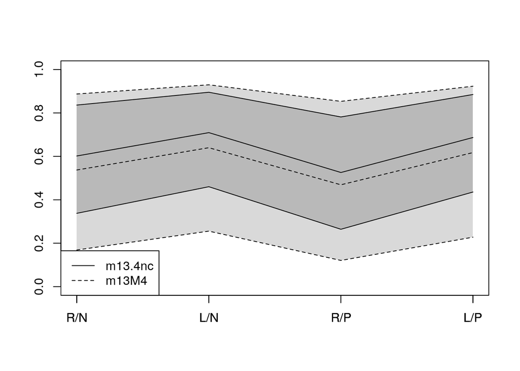

```r
p_link_abar <- function( treatment ) {
    logodds <- with( post , a_bar + b[,treatment] )
    return( inv_logit(logodds) )
}

post <- extract.samples(m13.4nc)
p_raw <- sapply( 1:4 , function(i) p_link_abar( i ) )
p_mu <- apply( p_raw , 2 , mean )
p_ci <- apply( p_raw , 2 , PI )

plot( NULL , xlab="treatment" , ylab="proportion pulled left" ,
    ylim=c(0,1) , xaxt="n" , xlim=c(1,4), ann=FALSE )
axis( 1 , at=1:4 , labels=c("R/N","L/N","R/P","L/P") )
lines( 1:4 , p_mu )
lines( 1:4 , p_ci[1,])
lines( 1:4 , p_ci[2,])
shade( p_ci , 1:4 )

post <- extract.samples(m13M4)
p_raw <- sapply( 1:4 , function(i) p_link_abar( i ) )
p_mu <- apply( p_raw , 2 , mean )
p_ci <- apply( p_raw , 2 , PI )

axis( 1 , at=1:4 , labels=c("R/N","L/N","R/P","L/P") )
lines( 1:4 , p_mu, lty=2 )
shade( p_ci , 1:4)
lines( 1:4 , p_ci[1,], lty=2 )
lines( 1:4 , p_ci[2,], lty=2 )
legend("bottomleft", legend=c("m13.4nc", "m13M4"), lty=c(1,2))
```

## 13H1.

Given: Bangladesh contraception data.

Want: Predict `use.contraception` clustered by `district_id`. (a) Fit a traditional fixed-effects model that uses dummy variables for district. (b) Fit a multilevel model with varying intercepts for district. Plot the predicted proportions of women in each district using contraception.

```r
data("bangladesh")
d <- bangladesh

sort(unique(d$district))
```

```
##  [1]  1  2  3  4  5  6  7  8  9 10 11 12 13 14 15 16 17 18 19 20 21 22 23 24 25
## [26] 26 27 28 29 30 31 32 33 34 35 36 37 38 39 40 41 42 43 44 45 46 47 48 49 50
## [51] 51 52 53 55 56 57 58 59 60 61
```

```r
d$district_id <- as.integer(as.factor(d$district))
sort(unique(d$district_id))
```

```
##  [1]  1  2  3  4  5  6  7  8  9 10 11 12 13 14 15 16 17 18 19 20 21 22 23 24 25
## [26] 26 27 28 29 30 31 32 33 34 35 36 37 38 39 40 41 42 43 44 45 46 47 48 49 50
## [51] 51 52 53 54 55 56 57 58 59 60
```

```r
head(d)
```

```
##   woman district use.contraception living.children age.centered urban
## 1     1        1                 0               4      18.4400     1
## 2     2        1                 0               1      -5.5599     1
## 3     3        1                 0               3       1.4400     1
## 4     4        1                 0               4       8.4400     1
## 5     5        1                 0               1     -13.5590     1
## 6     6        1                 0               1     -11.5600     1
##   district_id
## 1           1
## 2           1
## 3           1
## 4           1
## 5           1
## 6           1
```

```r
dat <- list(
    C = d$use.contraception,
    D = d$district_id)
```

```r
set.seed(13)
m13H1a <- ulam(
    alist(
        C ~ dbinom( 1 , p ) ,
        logit(p) <- a[D],
        a[D] ~ dnorm( 0 , 1 )
    ) , data=dat , chains=4 , cores=4 , log_lik=TRUE)
```

```r
set.seed(13)
m13H1b <- ulam(
    alist(
        C ~ dbinom( 1 , p ) ,
        logit(p) <- a[D],
        a[D] ~ dnorm( mu_a , sigma_a ),
        mu_a ~ dnorm(0, 1),
        sigma_a ~ dexp(1)
    ) , data=dat , chains=4 , cores=4 , log_lik=TRUE)
```

```r
set.seed(13)
d_agg <- aggregate(dat$C, by=list(D=dat$D), FUN=sum)
d_agg$p <- d_agg$x/max(d_agg$x)

m13H1a.sim.C <- sim(m13H1a, data=list(D=dat$D))
m13H1a.sim.C.mean <- apply(m13H1a.sim.C, 2, mean)
d13H1a_agg <- aggregate(m13H1a.sim.C.mean, by=list(D=dat$D), FUN=sum)
d13H1a_agg$p <- d13H1a_agg$x/max(d13H1a_agg$x)

m13H1b.sim.C <- sim(m13H1b, data=list(D=dat$D))
m13H1b.sim.C.mean <- apply(m13H1b.sim.C, 2, mean)
d13H1b_agg <- aggregate(m13H1b.sim.C.mean, by=list(D=dat$D), FUN=sum)
d13H1b_agg$p <- d13H1b_agg$x/max(d13H1b_agg$x)
```

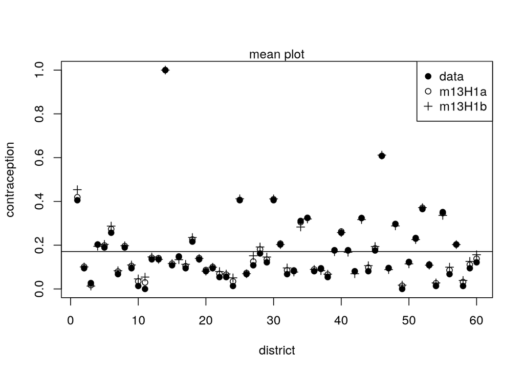

```r
plot(d_agg$D, d_agg$p, pch=19, xlab="district", ylab="contraception")
abline(h=mean(d_agg$p))
points(d13H1a_agg$D, d13H1a_agg$p, pch=1)
points(d13H1b_agg$D, d13H1b_agg$p, pch=3)
legend("topright", legend=c("data", "m13H1a", "m13H1b"), pch=c(19,1,3))
mtext("mean plot")
```

```r
mcoefs <- coeftab(m13H1a, m13H1b)@coefs
mdiff <- mcoefs[,1] - mcoefs[,2]
mdiff <- mdiff[order(mdiff)]
head(mdiff, n=10)
```

```
## a[11] a[24] a[10] a[58] a[49] a[56] a[27] a[22] a[32] a[60]
## -0.70 -0.40 -0.40 -0.31 -0.23 -0.18 -0.17 -0.15 -0.14 -0.13
```

- Generally m13H1b does produce slightly higher intercepts.
- The biggest difference between the mean values of the models are at district 11, 24,10, 58, 49.

Given: Trolley data.

Want: Varying intercepts model with `action`, `intention` and `contact` as ordinary terms, (a) with clustering intercepts on `id`, (b) without clustering. Compare with WAIC and posterior predictions.

Sol.:

```r
data(Trolley)
d <- Trolley

head(d)
```

```
##    case response order     id age male           edu action intention contact
## 1 cfaqu        4     2 96;434  14    0 Middle School      0         0       1
## 2 cfbur        3    31 96;434  14    0 Middle School      0         0       1
## 3 cfrub        4    16 96;434  14    0 Middle School      0         0       1
## 4 cibox        3    32 96;434  14    0 Middle School      0         1       1
## 5 cibur        3     4 96;434  14    0 Middle School      0         1       1
## 6 cispe        3     9 96;434  14    0 Middle School      0         1       1
##   story action2
## 1   aqu       1
## 2   bur       1
## 3   rub       1
## 4   box       1
## 5   bur       1
## 6   spe       1
```

```r
dat <- list(
    R = d$response,
    A = d$action,
    I = d$intention,
    C = d$contact,
    cid = as.factor(d$id))
str(dat)
```

```
## List of 5
##  $ R  : int [1:9930] 4 3 4 3 3 3 5 4 4 4 ...
##  $ A  : int [1:9930] 0 0 0 0 0 0 1 1 1 1 ...
##  $ I  : int [1:9930] 0 0 0 1 1 1 0 0 0 0 ...
##  $ C  : int [1:9930] 1 1 1 1 1 1 0 0 0 0 ...
##  $ cid: Factor w/ 331 levels "96;434","96;445",..: 1 1 1 1 1 1 1 1 1 1 ...
```

```r
m13H2a <- ulam(
    alist(
        R ~ dordlogit( phi , cutpoints ),
        phi <- bA[cid]*A + bI[cid]*I + bC[cid]*C,
        bA[cid] ~ dnorm( mu_b , sigma_b ),
        bI[cid] ~ dnorm( mu_b , sigma_b ),
        bC[cid] ~ dnorm( mu_b , sigma_b ),
        mu_b ~ dnorm( 0 , 0.5 ) ,
        sigma_b ~ dexp( 1 ),
        cutpoints ~ dnorm( 0 , 1.5 )
    ), data=dat , chains=4 , cores=4, log_lik = TRUE )
```

```r
m13H2b <- ulam(
    alist(
        R ~ dordlogit( phi , cutpoints ),
        phi <- bA[cid]*A + bI[cid]*I + bC[cid]*C,
        bA[cid] ~ dnorm( 0 , 0.5 ),
        bI[cid] ~ dnorm( 0 , 0.5 ),
        bC[cid] ~ dnorm( 0 , 0.5 ),
        cutpoints ~ dnorm( 0 , 1.5 )
    ), data=dat , chains=4 , cores=4, log_lik = TRUE )
```

```r
compare(m13H2a, m13H2b)
```

```
##            WAIC       SE    dWAIC      dSE    pWAIC weight
## m13H2a 32450.16 158.9381    0.000       NA 826.7952      1
## m13H2b 34370.96  88.6702 1920.801 92.73476 389.1488      0
```

```r
mcoefs <- coeftab(m13H2a, m13H2b)@coefs
mdiff <- mcoefs[,1] - mcoefs[,2]
mdiff <- mdiff[order(mdiff)]
head(mdiff, n=10)
```

```
## bC[138] bC[261] bA[261] bC[186]  bA[53]   bC[4]  bC[53] bA[138]   bA[3] bA[186]
##   -4.26   -4.15   -4.11   -4.09   -3.93   -3.93   -3.92   -3.85   -3.72   -3.72
```

```r
mdiff <- mdiff[order(-mdiff)]
head(mdiff, n=10)
```

```
## bA[147] bA[223] bA[141] bA[324] bA[308]   bA[8]  bC[93] bI[324] bI[223] bI[141]
##    1.52    1.51    1.51    1.51    1.42    1.39    1.34    1.34    1.34    1.32
```

- In terms of WAIC values the m13H2a performs better than m13H2b.

## 13H3.

Given: 13H2.

Want: Varying intercepts model with `action`, `intention` and `contact` as ordinary terms with clustering intercepts on `id` and `story`. Compare to 13H2.

Sol.:

```r
id_stories <- interaction(d$id,d$story, sep = ":")

str(id_stories)
```

```
##  Factor w/ 3972 levels "96;434:aqu","96;445:aqu",..: 1 994 2318 663 994 3311 1 332 663 994 ...
```

```r
dat <- list(
    R = d$response,
    A = d$action,
    I = d$intention,
    C = d$contact,
    cis = as.factor(id_stories)
)
str(dat)
```

```
## List of 5
##  $ R  : int [1:9930] 4 3 4 3 3 3 5 4 4 4 ...
##  $ A  : int [1:9930] 0 0 0 0 0 0 1 1 1 1 ...
##  $ I  : int [1:9930] 0 0 0 1 1 1 0 0 0 0 ...
##  $ C  : int [1:9930] 1 1 1 1 1 1 0 0 0 0 ...
##  $ cis: Factor w/ 3972 levels "96;434:aqu","96;445:aqu",..: 1 994 2318 663 994 3311 1 332 663 994 ...
```

[output not shown]